# R Code for Portfolio Optimization Chapter 8 – Portfolio Backtesting

Daniel P. Palomar (2025). [Portfolio Optimization: Theory and Application.](https://portfoliooptimizationbook.com/) Cambridge University Press.

Last update: March 10, 2025

# Loading packages

The following packages are used in the examples:

```r
# basic finance
library(xts)                    # to manipulate time series of stock data
library(PerformanceAnalytics)   # to compute performance measures
library(portfolioBacktest)      # to conduct backtests
library(pob)                    # book package with financial data
                                # install with: devtools::install_github("dppalomar/pob")

# plotting
library(ggplot2)                # for nice plots
library(reshape2)               # to reshape data

# optimization
library(CVXR)
```

# Market data and portfolios

For illustrative purposes, we simply choose a few stocks from the S&P 500 index during 2015-2020.

```r
data(SP500_2015to2020)
stock_prices <- SP500_2015to2020$stocks["2018::", c("AAPL", "AMZN", "AMD", "GM", "GOOGL", "MGM", "MSFT", "QCOM", "TSCO", "UPS")]

head(stock_prices)
```

```
             AAPL    AMZN   AMD      GM   GOOGL     MGM    MSFT    QCOM    TSCO
2018-01-02 41.514 1189.01 10.98 38.0722 1073.21 32.1285 82.5993 59.2277 72.8300
2018-01-03 41.506 1204.20 11.55 39.0012 1091.52 31.9559 82.9837 59.8999 73.3785
2018-01-04 41.699 1209.59 12.12 40.2035 1095.76 32.2723 83.7141 59.9817 74.6969
2018-01-05 42.174 1229.14 11.88 40.0851 1110.29 32.4928 84.7520 60.3814 76.4484
2018-01-08 42.017 1246.87 12.28 40.2764 1114.21 31.7354 84.8385 60.1997 76.2655
2018-01-09 42.012 1252.70 11.82 40.1216 1112.79 32.2435 84.7808 59.2913 76.4965
               UPS
2018-01-02 112.662
2018-01-03 115.158
2018-01-04 115.906
2018-01-05 116.261
2018-01-08 117.673
2018-01-09 117.618
```

```r
tail(stock_prices)
```

```
             AAPL    AMZN   AMD    GM   GOOGL   MGM   MSFT   QCOM    TSCO
2020-09-15 115.54 3156.13 78.93 31.58 1535.12 23.74 208.78 116.58 140.880
2020-09-16 112.13 3078.10 76.66 31.79 1512.09 23.01 205.05 114.56 138.250
2020-09-17 110.34 3008.73 76.55 31.92 1487.04 22.52 202.91 114.88 138.150
2020-09-18 106.84 2954.91 74.93 31.50 1451.09 22.02 200.39 110.69 138.110
2020-09-21 110.08 2960.47 77.94 30.00 1430.14 21.09 202.54 111.92 137.555
2020-09-22 111.81 3128.99 77.70 29.44 1459.82 21.62 207.42 113.82 141.610
              UPS
2020-09-15 161.53
2020-09-16 159.87
2020-09-17 159.75
2020-09-18 159.66
2020-09-21 161.06
2020-09-22 161.89
```

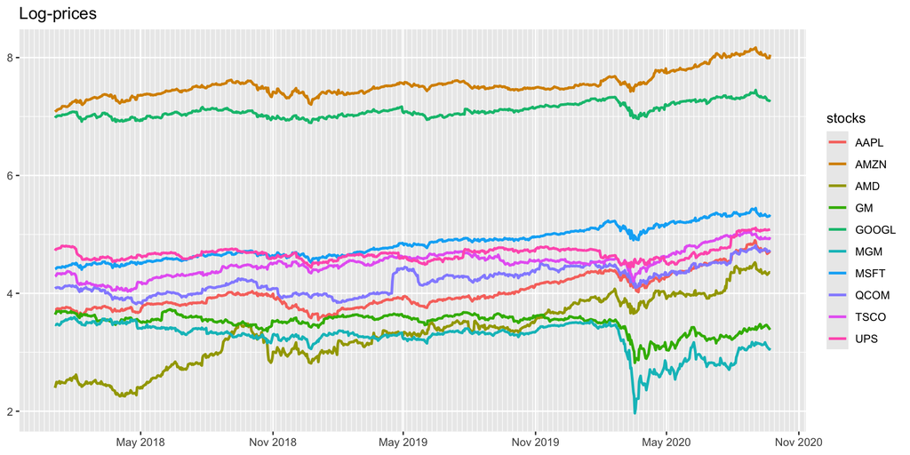

```r
log(stock_prices) |>
  fortify(melt = TRUE) |>
  ggplot(aes(x = Index, y = Value, color = Series)) +
  geom_line(linewidth = 1) +
  scale_x_date(date_breaks = "6 months", date_labels = "%b %Y", date_minor_breaks = "1 week") +
  labs(title = "Log-prices", x = NULL, y = NULL, color = "stocks")
```

Also for illustrative purposes, we choose the following three simple portfolios:

- $1/N$ portfolio:
  $$\w = \frac{1}{N}\bm{1};$$
- Global minimum variance portfolio (GMVP):
  $$\begin{array}{ll}
  \underset{\w}{\textm{minimize}} & \w^\T\bSigma\w\\
  \textm{subject to} & \bm{1}^\T\w=1, \quad \w\ge\bm{0};
  \end{array}$$
- Inverse volatility portfolio (IVP):
  $$\w = \frac{\bm{\sigma}^{-1}}{\bm{1}^\T\bm{\sigma}^{-1}}.$$

```r
one_over_N <- function(dataset, ...) {
  N <- ncol(dataset$prices)
  return(rep(1/N, N))
}

design_GMVP <- function(Sigma) {
  w <- Variable(nrow(Sigma))
  prob <- Problem(Minimize(quad_form(w, Sigma)),
                  constraints = list(w >= 0, sum(w) == 1))
  result <- solve(prob)
  w <- as.vector(result$getValue(w))
  return(w)
}

GMVP <- function(dataset, ...) {
  N <- ncol(dataset$prices)
  X <- diff(log(dataset$prices))[-1]
  Sigma <- cov(X)
  w <- design_GMVP(Sigma)
  return(w)
}

design_IVP <- function(sigma) {
  w <- 1/sigma
  w <- w/sum(w)
  return(w)
}

IVP <- function(dataset, ...) {
  N <- ncol(dataset$prices)
  X <- diff(log(dataset$prices))[-1]
  sigma <- apply(X, 2, sd, na.rm = TRUE)
  w <- design_IVP(sigma)
  return(w)
}
```

# Vanilla backtesting

Vanilla backtesting refers to simply dividing the available data intro training data (for the portfolio design) and test data (for the portfolio assessment).

## Daily rebalancing ignoring transaction costs

If we assume a daily rebalancing (with daily data) and ignore transaction costs, then the backtest is very simple to perform simply by multiplying the matrix of assets’ linear returns by the portfolio vector.

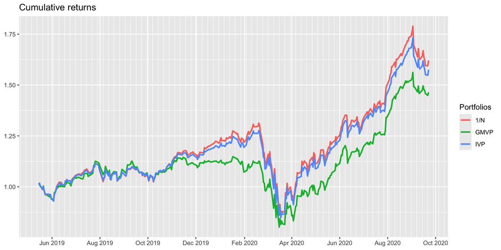

```r
# compute linear and log-returns
X_lin <- stock_prices/lag(stock_prices) - 1
X_log <- diff(log(stock_prices))

# split data into training and test data
N <- ncol(stock_prices)
T <- nrow(stock_prices)
T_trn <- round(0.50*T)
X_lin_trn <- X_lin[1:T_trn, ]
X_lin_tst <- X_lin[-c(1:T_trn), ]
X_log_trn <- X_log[1:T_trn, ]
X_log_tst <- X_log[-c(1:T_trn), ]

# estimate mu and Sigma with training data (removing first row of NAs)
mu    <- colMeans(X_log_trn[-1, ])
Sigma <- cov(X_log_trn[-1, ])

# design portfolios
w_one_over_N <- rep(1/N, N)
w_GMVP       <- design_GMVP(Sigma)
w_IVP        <- design_IVP(sqrt(diag(Sigma)))

# backtest portfolios with test data (assuming daily rebalancing and no transaction cost)
ret_one_over_N <- xts(X_lin_tst %*% w_one_over_N, index(X_lin_tst))
ret_GMVP       <- xts(X_lin_tst %*% w_GMVP,       index(X_lin_tst))
ret_IVP        <- xts(X_lin_tst %*% w_IVP,        index(X_lin_tst))

# compute cumulative returns or wealth or NAV
wealth_one_over_N <- cumprod(1 + ret_one_over_N)
wealth_GMVP       <- cumprod(1 + ret_GMVP)
wealth_IVP        <- cumprod(1 + ret_IVP)

# plot
cbind("1/N"   = wealth_one_over_N,
      "GMVP"  = wealth_GMVP,
      "IVP"   = wealth_IVP,
      check.names = FALSE) |>
  fortify(melt = TRUE) |>
  ggplot(aes(x = Index, y = Value, color = Series)) +
  geom_line(linewidth = 1) +
  scale_x_date(date_breaks = "2 months", date_labels = "%b %Y", date_minor_breaks = "1 week") +
  labs(title = "Cumulative returns", x = NULL, y = NULL, color = "Portfolios")
```

We can now conveniently reproduce the same backtest using the package [`portfolioBacktest`](https://cran.r-project.org/package=portfolioBacktest):

```r
# perform backtest
bt <- portfolioBacktest(portfolio_funs = list("1/N"  = one_over_N,
                                              "GMVP" = GMVP,
                                              "IVP"  = IVP),
                        dataset_list = list("dataset1" = list("prices" = stock_prices)), price_name = "prices",
                        lookback = T_trn, optimize_every = 10000, rebalance_every = 1)
```

```
Backtesting 3 portfolios over 1 datasets (periodicity = daily data)...
```

```r
# sanity check
all(
  all.equal(ret_one_over_N, bt$`1/N`$dataset1$return,  check.attributes = FALSE),
  all.equal(ret_GMVP,       bt$`GMVP`$dataset1$return, check.attributes = FALSE),
  all.equal(ret_IVP,        bt$`IVP`$dataset1$return,  check.attributes = FALSE)
)
```

```
[1] TRUE
```

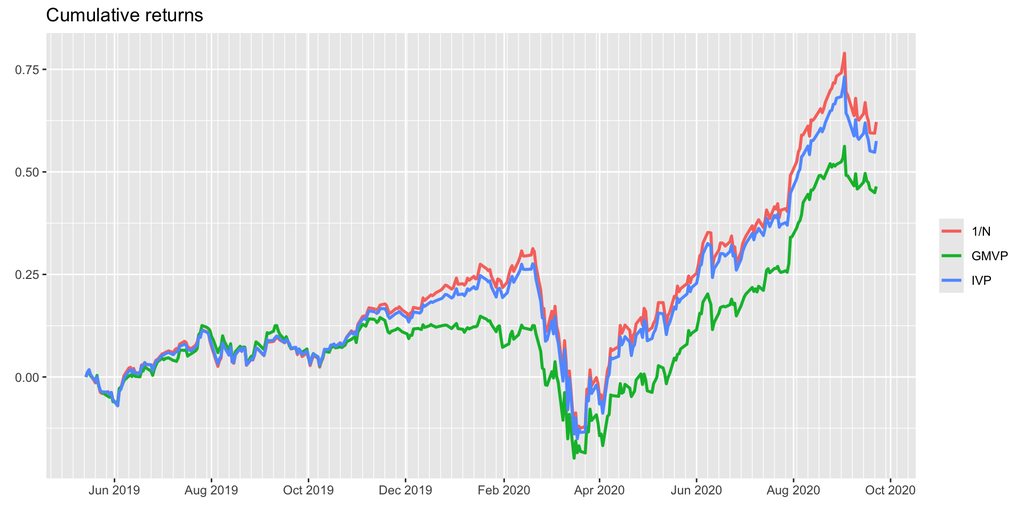

```r
# plot
backtestChartCumReturn(bt) +
  scale_x_date(date_breaks = "2 months", date_labels = "%b %Y", date_minor_breaks = "1 week") +
  ggtitle("Cumulative returns")
```

## Realistic rebalancing including transaction costs

We can now easily include transaction costs (say, of 60 bps) in the backtest and even reducing the rebalancing period to every week or 5 days (instead of daily) using the package [`portfolioBacktest`](https://cran.r-project.org/package=portfolioBacktest):

```r
# perform backtest
bt <- portfolioBacktest(portfolio_funs = list("1/N"  = one_over_N,
                                              "GMVP" = GMVP,
                                              "IVP"  = IVP),
                        dataset_list = list("dataset1" = list("prices" = stock_prices)), price_name = "prices",
                        lookback = T_trn, optimize_every = 10000, rebalance_every = 5,
                        cost = list(buy = 60e-4, sell = 60e-4))
```

```
Backtesting 3 portfolios over 1 datasets (periodicity = daily data)...
```

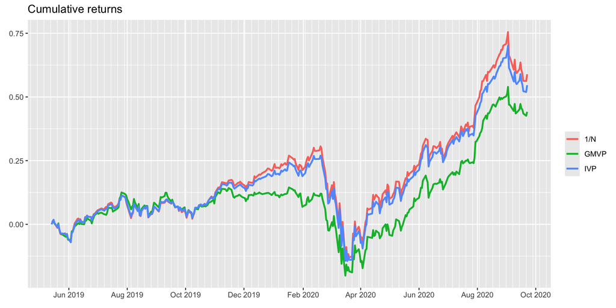

```r
# plot
backtestChartCumReturn(bt) +
  scale_x_date(date_breaks = "2 months", date_labels = "%b %Y", date_minor_breaks = "1 week") +
  ggtitle("Cumulative returns")
```

# Walk-forward backtesting

Now, rather than keeping the portfolio fixed during all the test data, we can perform a walk-forward backtest by reoptimizing the portfolio every, say, 1 month or 20 days, on a rolling-window basis.

```r
# perform backtest
bt <- portfolioBacktest(portfolio_funs = list("1/N"  = one_over_N,
                                              "GMVP" = GMVP,
                                              "IVP"  = IVP),
                        dataset_list = list("dataset1" = list("prices" = stock_prices)), price_name = "prices",
                        lookback = T_trn, optimize_every = 20, rebalance_every = 5,
                        cost = list(buy = 60e-4, sell = 60e-4))
```

```
Backtesting 3 portfolios over 1 datasets (periodicity = daily data)...
```

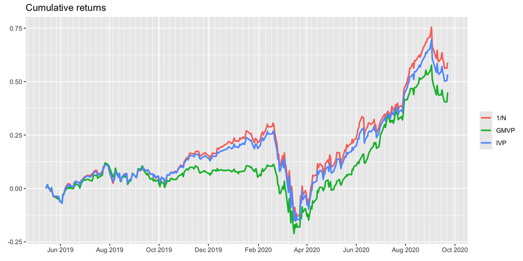

```r
# plot
backtestChartCumReturn(bt) +
  scale_x_date(date_breaks = "2 months", date_labels = "%b %Y", date_minor_breaks = "1 week") +
  ggtitle("Cumulative returns")
```

Since the portfolios are changing over time, we can plot the evolution of the portfolios over time:

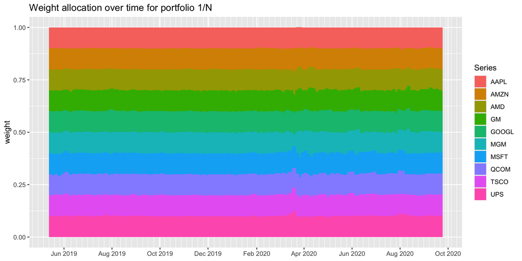

```r
bt$`1/N`$dataset1$w_bop |>
  fortify(melt = TRUE) |>
  ggplot(aes(x = Index, y = Value, fill = Series)) +
  geom_bar(stat = "identity", width = 4.0) +
  scale_x_date(date_breaks = "2 months", date_labels = "%b %Y", date_minor_breaks = "1 week") +
  labs(title = "Weight allocation over time for portfolio 1/N", x = NULL, y = "weight", color = "stocks")
```

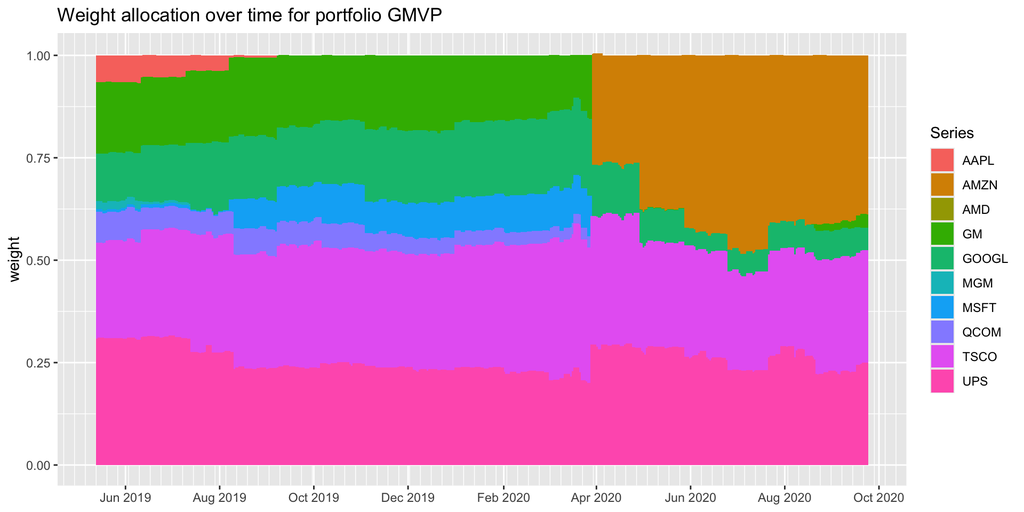

```r
bt$`GMVP`$dataset1$w_bop |>
  fortify(melt = TRUE) |>
  ggplot(aes(x = Index, y = Value, fill = Series)) +
  geom_bar(stat = "identity", width = 4.0) +
  scale_x_date(date_breaks = "2 months", date_labels = "%b %Y", date_minor_breaks = "1 week") +
  labs(title = "Weight allocation over time for portfolio GMVP", x = NULL, y = "weight", color = "stocks")
```

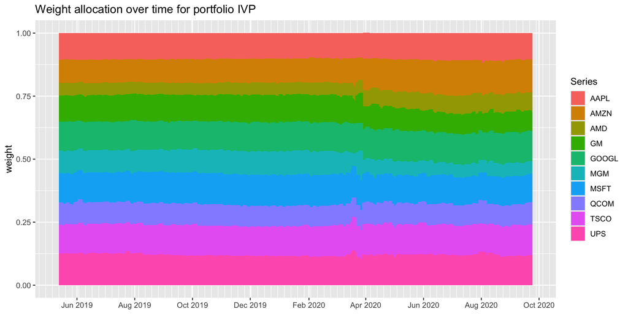

```r
bt$`IVP`$dataset1$w_bop |>
  fortify(melt = TRUE) |>
  ggplot(aes(x = Index, y = Value, fill = Series)) +
  geom_bar(stat = "identity", width = 4.0) +
  scale_x_date(date_breaks = "2 months", date_labels = "%b %Y", date_minor_breaks = "1 week") +
  labs(title = "Weight allocation over time for portfolio IVP", x = NULL, y = "weight", color = "stocks")
```

# Multiple randomized backtesting

Finally, rather than running a single backtest, we can introduce some randomness in the data and perform, say, 200 randomized backtests (Palomar, 2025, Chapter 8). Again, this can be conveniently done with the package [`portfolioBacktest`](https://cran.r-project.org/package=portfolioBacktest).

First, we resample 200 times the original data of $N=10$ stocks over 2017-2020. Each time we select randomly $N=8$ stocks and a random period of two years.

```r
data(SP500_2015to2020)
stock_prices <- SP500_2015to2020$stocks["2017::", c("AAPL", "AMZN", "AMD", "GM", "GOOGL", "MGM", "MSFT", "QCOM", "TSCO", "UPS")]

# resample data
stock_prices_resampled <- financialDataResample(list("prices" = stock_prices),
                                                num_datasets = 200, N_sample = 8, T_sample = 252*2)
```

```
200 datasets resampled (with N = 8 instruments and length T = 504) from the original data between 2017-01-03 and 2020-09-22.
```

Then, we perform the backtest (this will take some time):

```r
# perform multiple backtest on the resampled data
bt <- portfolioBacktest(portfolio_funs = list("1/N"  = one_over_N,
                                              "GMVP" = GMVP,
                                              "IVP"  = IVP),
                        dataset_list = stock_prices_resampled,
                        lookback = 252, optimize_every = 20, rebalance_every = 5,
                        paral_datasets = 6,
                        cost = list(buy = 60e-4, sell = 60e-4))
```

```
Backtesting 3 portfolios over 200 datasets (periodicity = daily data)...
```

Now we can show the results in a table form:

```r
summary_bt <- backtestSummary(bt)
summaryTable(summary_bt, type = "DT", order_col = "Sharpe ratio", order_dir = "desc",
             measures = c("annual return", "annual volatility", "max drawdown",
                          "Sharpe ratio", "Sortino ratio", "Sterling ratio",
                          "VaR (0.95)", "CVaR (0.95)"))
```

|  | annual return | annual volatility | max drawdown | Sharpe ratio | Sortino ratio | Sterling ratio | VaR (0.95) | CVaR (0.95) |
| --- | --- | --- | --- | --- | --- | --- | --- | --- |
| 1/N | 0.25 | 0.25 | 0.24 | 0.94 | 1.33 | 0.97 | 0.03 | 0.04 |
| GMVP | 0.15 | 0.22 | 0.24 | 0.66 | 0.94 | 0.71 | 0.02 | 0.03 |
| IVP | 0.22 | 0.23 | 0.23 | 0.85 | 1.2 | 0.9 | 0.02 | 0.03 |

And we can also show the results in the form of barplots or boxplots:

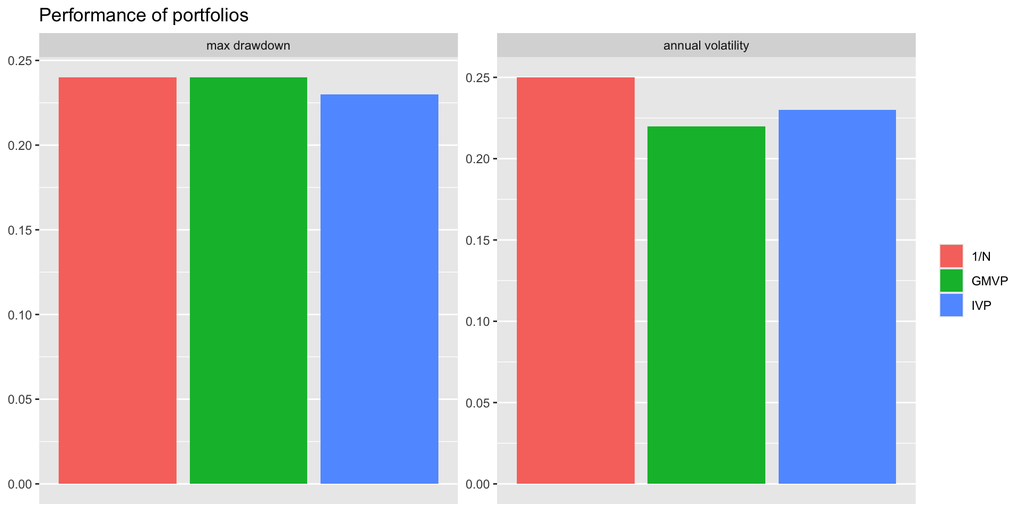

```r
summaryBarPlot(summary_bt, measures = c("max drawdown", "annual volatility"))
```

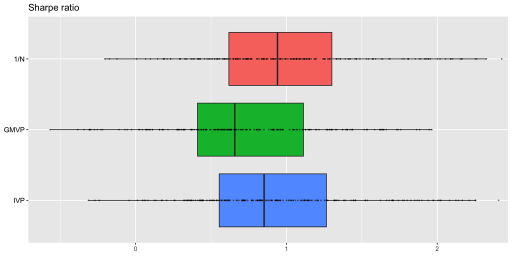

```r
backtestBoxPlot(bt, "Sharpe ratio")
```

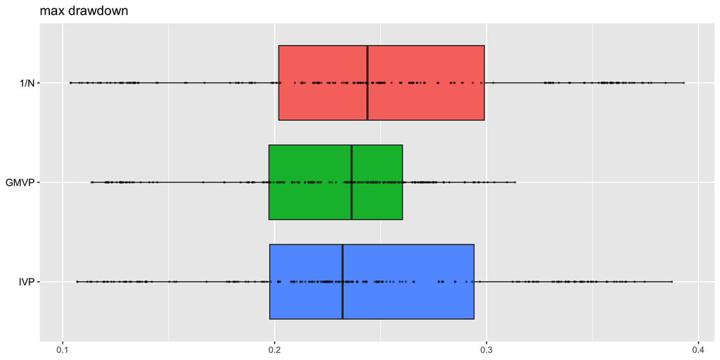

```r
backtestBoxPlot(bt, "max drawdown")
```

## References

Palomar, D. P. (2025). *Portfolio optimization: Theory and application*. Cambridge University Press.